# 03 - Aula de Estimativa e Correlação

Estatística

Essa aula irá abordar os conceitos e exemplos de estimativa e correlação que fazem parte da estatística aplicada à pesquisa.

Author

Affiliation

Ludmilla Rodrigues Santana Borges

Universidade Federal da Bahia (UFBA)

Published

May 4, 2026

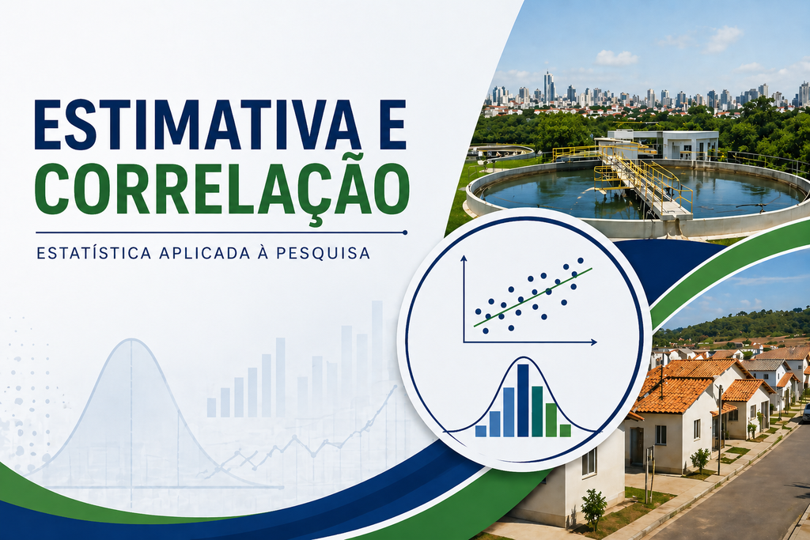

ChatGPT Image 30_04_2026, 11_35_57.png

# **Aula de Estimativa e Correlação**

Essa aula irá abordar os conceitos e exemplos de estimativa e correlação que fazem parte da estatística aplicada à pesquisa.

Os exemplos aqui apresentados irão abordar estudos voltados à implantação de projetos de saneamento básico.

## **1.Estimação de Parâmetros**

Primeiramente, vamos partir do **conceito central** da estatística sobre a estimação:

### “Estimação é o processo de usar dados de uma **amostra** para **inferir** valores **desconhecidos** de uma população.”

Ou seja, diante da **inviabilidade de medir** toda uma população, seja por custo, tempo ou operacionalização, **usa-se uma amostra** e a partir dessa amostra é feita a **estimativa sobre o conjunto da população** ao qual se deseja representar.

Importante destacar que, para a estimativa ser confiável, é fundamental que a amostra seja:

- Representativa;
- Aleatória;
- Suficiente;
- Adequadamente distribuída.

Exemplos comuns de estimativas:

- Média - Média entre os elementos da amostra (x)
- Desvio padrão - Desvio padrão entre os elementos da amostra (S)
- Proporção - Proporção entre os elementos da amostra (P)

**E quais são os parâmetros? O que são eles?**

Os parâmetros são os valores que são utilizados para descrever as características da população, ou seja, são valores reais da população, geralmente desconhecidos, que buscamos estimar a partir de uma amostra.

Os exemplos mais comuns de parâmetros são:

- Média populacional - Valor médio da população (u)
- Desvio padrão - Dispersão dos dados da população (o)
- Proporção - Percentual proporcional da população (π)

**E qual a diferença?**

- Parâmetro pertence a população, é um valor fixo e desconhecido.
- Estimativa vem da amostra, é um valor calculado.

A partir disso, utilizamos os dados da amostra, para estimar o parâmetro da população.

**Tipos de Estimação de Parâmetros:**

- Pontual: A estimativa é representada por um único valor.

Exemplo: Média da amostra (x) estimando a média da população (u)

- Intervalo: A estimativa é representada por um intervalo de valores onde o parâmetro provavelmente está, com um nível de confiança.

Exemplo: A média de idade da população está entre 10 e 15, com 95% de confiança.

**Informações necessárias para estimar parâmetros - O que aparece nos cálculos:**

- Tamanho da amostra (n)
- Tamanho da população (N, opcional)
- Média ou proporção amostral (x ou p)
- Desvio padrão (s)
- Nível de confiança (z)

**1.2 Aplicação da Estimação de Parâmetros**

Situação: Uma área está sendo estudada para verificar a necessidade de um projeto de implantação de redes de esgoto (ou água). A poligonal possui 3.500 imóveis, contudo, foi realizada uma amostragem com 2.000 imóveis com o objetivo de identificar a demanda por essa infraestrutura, com um nível de confiança de 95%. Vamos considerar que se mais de 70% dos imóveis não possuir a infraestrutura básica, será necessario o projeto para implantação.

**Base de dados:**

Os dados coletados em campo foram organizados em uma planilha Excel, contendo:

- Uma coluna para água
- Uma coluna para esgoto

Em ambas, os valores são:

- SIM - Possui acesso ao serviço
- NÃO - Não possui acesso ao serviço

Para começarmos, precisamos ajustar os dados dessa planilha, pois os cálculos estatísticos são feitos com dados numéricos, não com textos.

Então vamos definir:

- NÃO - 1
- SIM - 0

Dessa forma, é possível estimar a proporção de imóveis sem acesso à infraestrutura, a partir dos dados da amostra.

O passo a passo para calcular esse exemplo será o seguinte:

1. Conectar o google colab ao google drive (onde está salvo a base dados - planilha)
2. Definir o caminho do arquivo
3. Ler a planilha
4. Preparar os dados
5. Estimação pontual
6. Estimação por intervalo
7. Estimativa para a população (3.500 imóveis)
8. Resultados e gráfico

Para realizar todas essas etapas, utilizaremos as seguintes bibliotecas:

- pandas - leitura e manipulação da planilha
- numpy - operações numéricas
- math - cálculo da raiz quadrada
- matplotlib - criação de gráficos
- scipy.stats - estatística e probabilidade
- google.colab.drive - acesso ao Google Drive

```
População (N): 3500
Amostra (n): 2000
Estimativa de imóveis sem esgoto: 3160
Proporção pontual: 90.30%
O percentual estimado de imóveis sem acesso a rede de esgoto está entre 89.45% e 91.15%, com 95% de confiança nos dados.
O resultado final é de 90.30% de imóveis sem esgoto, então existe a necessidade de implantação da infraestrutura.
```

[figure not shown]

# **Exemplo 2: Preciso definir o tamanho da amostra, para estimar dados sobre uma população.**

**Porque é necessário definir o tamanho mínimo de uma amostra?**

Ao definir o tamanho mínimo de uma amostra, é possível garantir o nível de confiança e da precisão das conclusões estatísticas, pois a amostra precisa ser o suficiente para representar a população, mas não maior que o necessário, de modo a evitar custos excessivos e perda de tempo.

Nesse mesmo contexto, se a amostra for pequena demais pode ocorrer: * Resultados instáveis * Alta margem de erro * Baixa representatividade * Conclusões pouco confiáveis

O objetivo real do cálculo de definição de amostra é: * Garantir precisão * Evitar custos excessivos * Representatividade que reflita a população

Aqui precisamos definir as regras necessárias, como:

- Tamanho da população (N)
- Nivél de confiança (z)
- Margem de erro amostral (E)
- Proporção esperada (p)

Para esse exemplo vamos utilizar as seguintes bibliotecas:

- math - cálculo da raiz quadrada
- scipy.stats - estatística e probabilidade

```
Tamanho mínimo da amostra: 347
```

### Com o exemplo acima, é possível afirmar que considerando uma **população de 3500 imóveis**, uma **amostra mínima de aproximadamente 347** observações já seria **suficiente** para estimar a proporção populacional com 95% de confiança e margem de erro de 5%.

## **2. Correlação**

Vamos partir do **conceito central** da estatística sobre a correlação:

### “A correlação é um método estatístico que **mede o grau de associação** entre **duas variáveis**, ou seja, como elas variam juntas”

Ou seja, é um método para compreender o comportamento do conjunto de dados e responder as seguintes perguntas:

- Quando uma variável aumenta, a outra também aumenta?
- Quando uma aumenta, a outra diminui?
- Existe alguma relação entre elas?
- Essa relação é forte ou fraca?

**Tipos de correlação:**

- Positiva - Quando uma variável aumenta, a outra também aumenta
- Negativa - Quando uma variável aumenta a outra diminui
- Nula - Não existe relação aparente entre as variáveis

Para essa aula, duas correlações serão exemplificadas, que são as mais comuns:

- **Correlação de Pearson:**

Calcula o grau de correlação (a intensidade da direção) da relação linear entre duas variáveis numéricas. Essas variáveis **variam de -1 a 1** e quanto mais próximo de 0, é possivel afirmar que as variáveis não possuem relação linear (**nula**), contudo, quando o valor estimado for mais proximo de -1, podemos afirmar que as variáveis apresentam correlação linear **negativa** e quanto mais proximo de 1, uma relação linear **positiva**.

Em resumo:

**r = representa o coeficiente de correlação** 1. r= 1 correlação positiva perfeita 2. r> 0 correlação positiva 3. r= 0 ausência de correlação linear 4. r< 0 correlação negativa 5. r= -1 correlação negativa perfeita

- **Correlação de Spearman**

Calcula o grau de correlação entre duas variáveis, mas não necessariamente linear. Nessa correlação, é utilizado rankings para efetuar os calculos de correlação. Assim como a correlação de Pearson, a de Spearman também vária de -1 a 1, seguindo a mesma lógica.

Situação: A amostragem dos 2.000 imóveis para identificar a demanda por infraestrutura, também coletou informações sobre a renda das famílias. Vamos calcular então a relação entre a renda com acesso a rede de esgoto, utilizando as correlações de Pearson e de Spearman.

Esses cálculos vão mostrar se existe relação de renda com a ausência da infraestrutura de esgoto.

Para realizar os cálculos, utilizaremos as seguintes bibliotecas:

- pandas - leitura e manipulação da planilha
- matplotlib - criação de gráficos
- numpy - operações numéricas
- scipy.stats - estatística e probabilidade
- google.colab.drive - acesso ao Google Drive

O passo a passo para calcular esse exemplo será o seguinte:

1. Conectar o google colab ao google drive (onde está salvo a base dados - planilha)
2. Definir o caminho do arquivo e ler a planilha
3. Preparar os dados
4. Correlação de Pearson
5. Correlação de Spearman
6. Resultados

```
📊 Correlação de Pearson
Coeficiente de correlação (r) = -0.0666
p-valor (significância estatística) = 0.0029
✔ Resultado estatisticamente significativo (α = 0.05).
➡ Existe correlação linear negativa.

📊 Correlação de Spearman
Coeficiente de correlação (ρ) = -0.0975
p-valor (significância estatística) = 0.0000
✔ Resultado estatisticamente significativo (α = 0.05).
➡ Existe correlação monotônica negativa.
```

**Fontes e leituras complementares:** * [Estatística aplicada à pesquisa - Estimação de Parâmetros - Profa. Sonia Muller (UFPR)](https://docs.ufpr.br/~soniaisoldi/TP707/Aula5.pdf) * [Estimação Estatística - Editora Pantanal](https://www.editorapantanal.com.br/ebooks/2021/estimacao-estatistica/ebook.pdf) * [Data Science - Um guia teórico de ciência de dados e machine larning - Luiza Reixach Castro](https://drive.google.com/file/d/1fwK9qhWDiTkfIHdw8TGrjlyIonSv1CUX/view?usp=sharing)

Source: **Aula de Estimativa e Correlação**